# Part 1: Wrangling

```python
import sqlite3 as sql
import pandas as pd
import matplotlib.pyplot as plt
import numpy as np
```

```python
# toggle off row display limit
pd.set_option("display.max_rows", None)
pd.set_option("display.max_columns", None)
```

```python
# toggle on row display limit
pd.set_option("display.max_rows", 10)
pd.set_option("display.max_columns", 5)
```

### Problem 1

```python
sqlite_file = "lahman2014.sqlite"
conn = sql.connect(sqlite_file)
```

```python
# sql code to retrieve the data of interest from the database
teams_query = """
                SELECT
                    A.yearID,
                    A.teamID,
                    franchID,
                    W,
                    G,
                    100*CAST(W AS float)/CAST(G AS float) AS winPercent,
                    payroll
                FROM
                    Teams A
                INNER JOIN
                    (SELECT yearID, teamID, SUM(salary) AS payroll FROM Salaries GROUP BY yearID, teamID) B
                ON
                    A.yearID = B.yearID AND A.teamId = B.teamId
            """

# runs the sql code and stores the data in a dataframe
teams = pd.read_sql(teams_query, conn)
```

```python
teams
```

|  | yearID | teamID | ... | winPercent | payroll |
| --- | --- | --- | --- | --- | --- |
| 0 | 1985 | ATL | ... | 40.740741 | 14807000.0 |
| 1 | 1985 | BAL | ... | 51.552795 | 11560712.0 |
| 2 | 1985 | BOS | ... | 49.693252 | 10897560.0 |
| 3 | 1985 | CAL | ... | 55.555556 | 14427894.0 |
| 4 | 1985 | CHA | ... | 52.147239 | 9846178.0 |
| ... | ... | ... | ... | ... | ... |
| 853 | 2014 | SLN | ... | 55.555556 | 120693000.0 |
| 854 | 2014 | TBA | ... | 47.530864 | 72689100.0 |
| 855 | 2014 | TEX | ... | 41.358025 | 112255059.0 |
| 856 | 2014 | TOR | ... | 51.234568 | 109920100.0 |
| 857 | 2014 | WAS | ... | 59.259259 | 131983680.0 |

858 rows × 7 columns

I used the `read_sql()` function in Pandas to extract data from the SQLite database and put it into a Pandas database. In my SQL query, I used the `GROUP BY` statement to sum all of the salaries for each team/year combination in the Salaries table, and then used the `INNER JOIN` statement to combine the resulting table with selected data from the Teams table.

As a result of using `INNER JOIN`, team/year combinations that existed in one table but not the other (missing data) were not included in the final table. Therefore the final table does not have any data from before 1985, which is the earliest year of recorded data in the Salaries table.

For both of these tables, when the row exists, all variables in the row seem to exist.

# Part 2: Exploratory Data Analysis

## Payroll Distribution

### Problem 2

```python
# organizes dataframe for analyzing payrolls
payrolls = teams.drop(teams.columns.difference(["yearID", "teamID", "payroll"]), 1).set_index("yearID")

# removes years before 1985-1989, we're only looking at 1990-2014
payrolls = payrolls.drop(index=[1985, 1986, 1987, 1988, 1989])
```

```python
payrolls
```

| yearID | teamID | payroll |
| --- | --- | --- |
| 1990 | ATL | 14555501.0 |
| 1990 | BAL | 9680084.0 |
| 1990 | BOS | 20558333.0 |
| 1990 | CAL | 21720000.0 |
| 1990 | CHA | 9491500.0 |
| ... | ... | ... |
| 2014 | SLN | 120693000.0 |
| 2014 | TBA | 72689100.0 |
| 2014 | TEX | 112255059.0 |
| 2014 | TOR | 109920100.0 |
| 2014 | WAS | 131983680.0 |

728 rows × 2 columns

```python
# "unmelts"; creates a seperate column for each team, index is still yearID
payrolls_team_cols = payrolls.pivot(columns="teamID")
```

```python
payrolls_team_cols
```

| teamID yearID | payroll ANA | payroll ARI | payroll ... | payroll TOR | payroll WAS |
| --- | --- | --- | --- | --- | --- |
| 1990 | NaN | NaN | ... | 17756834.0 | NaN |
| 1991 | NaN | NaN | ... | 19902417.0 | NaN |
| 1992 | NaN | NaN | ... | 44788666.0 | NaN |
| 1993 | NaN | NaN | ... | 47279166.0 | NaN |
| 1994 | NaN | NaN | ... | 43433668.0 | NaN |
| ... | ... | ... | ... | ... | ... |
| 2010 | NaN | 60718166.0 | ... | 62234000.0 | 61400000.0 |
| 2011 | NaN | 53639833.0 | ... | 62567800.0 | 63856928.0 |
| 2012 | NaN | 73804833.0 | ... | 75009200.0 | 80855143.0 |
| 2013 | NaN | 90132000.0 | ... | 126288100.0 | 113703270.0 |
| 2014 | NaN | 97861500.0 | ... | 109920100.0 | 131983680.0 |

25 rows × 35 columns

```python
# removes "payroll" from column names for cleaner legend when plotted
payrolls_team_cols.columns = payrolls_team_cols.columns.droplevel()
```

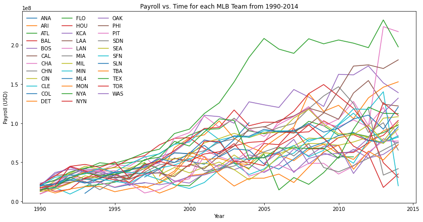

```python
# plots the data
fig, axes = plt.subplots(nrows=1, ncols=1, figsize=(14, 7))
payrolls_team_cols.plot(ax=axes, title = "Payroll vs. Time for each MLB Team from 1990-2014")
plt.setp(axes, xlabel="Year", ylabel="Payroll (USD)")

# customizes legend
_ = axes.legend(frameon=False, loc='upper left', ncol=3)
```

To show the distribution of payrolls across teams conditioned on time I chose to plot lines showing each team's payroll and how it's changed over time from 1990-2014. I did this by first "unmelting" the table using `.pivot()` to give each team it's own column showing payroll for each year. From that I could easily plot the data using `.plot()`.

### Question 1

Looking at the graph, it's clear that the spread of payrolls increases a lot between 1990 and 2014—the lines are very close together (from the perspective the graph provides) in 1990, and very far apart in 2014. From this we can deduce that the variance/standiard deviation of the distribution of payrolls across teams increases over this time span.

The graph also shows a general upward trend in payrolls over time; if you imagine drawing a best fit line on the graph, you can see it would slope upward. Therefore, the graph shows that the average payroll of teams in the MLB increases from 1990-2014.

### Problem 3

```python
# creates groupby object with the leage's total payrolls for each year
# object can be used to find mean, std deviation, etc of payrolls for each year
payrolls_by_year = payrolls.groupby("yearID")
```

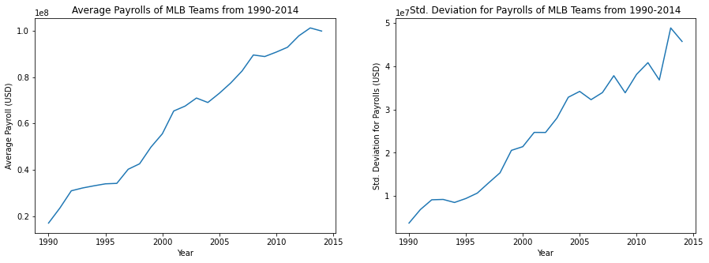

```python
# plots the data
fig, axes = plt.subplots(nrows=1, ncols=2, figsize=(15, 5))
payrolls_by_year.mean().plot(ax=axes[0], legend=False, ylabel="Average Payroll (USD)",
                     title="Average Payrolls of MLB Teams from 1990-2014")
payrolls_by_year.std().plot(ax=axes[1], legend=False, ylabel="Std. Deviation for Payrolls (USD)",
                    title="Std. Deviation for Payrolls of MLB Teams from 1990-2014")
_ = plt.setp(axes, xlabel="Year")
```

To get these two graphs, I used `groupby()` to get a groupby object that I could call `.mean()` and `.std()` on to get the mean payroll and standard deviation at each year. I could then plot the data easily using `.plot()`.

## Correlation between payroll and winning percentage

### Problem 4

```python
# puts each index from the teams dataframe in a bin based on its year
years = teams.iloc[:, 0].rename("bin")
bins = pd.cut(x=years, bins=[1990, 1995, 2000, 2005, 2010, 2015], labels=["A", "B", "C", "D", "E"], right=False)

# creates new dataframe with a bin column and select columns from the teams dataframe
binned = teams.drop(teams.columns.difference(["teamID", "winPercent", "payroll"]), 1).join(bins)
```

```python
binned
```

|  | teamID | winPercent | payroll | bin |
| --- | --- | --- | --- | --- |
| 0 | ATL | 40.740741 | 14807000.0 | NaN |
| 1 | BAL | 51.552795 | 11560712.0 | NaN |
| 2 | BOS | 49.693252 | 10897560.0 | NaN |
| 3 | CAL | 55.555556 | 14427894.0 | NaN |
| 4 | CHA | 52.147239 | 9846178.0 | NaN |
| ... | ... | ... | ... | ... |
| 853 | SLN | 55.555556 | 120693000.0 | E |
| 854 | TBA | 47.530864 | 72689100.0 | E |
| 855 | TEX | 41.358025 | 112255059.0 | E |
| 856 | TOR | 51.234568 | 109920100.0 | E |
| 857 | WAS | 59.259259 | 131983680.0 | E |

858 rows × 4 columns

```python
means = binned.groupby(by=["bin", "teamID"]).mean()
```

```python
means

# some bins have NaN because the teams don't exist in that time period,
# for example the Diamonbacks (ARI) weren't founded until 1998, so they're NaN in bin A (1990-1994)
```

| bin | teamID | winPercent | payroll |
| --- | --- | --- | --- |
| A | ANA | NaN | NaN |
|  | ARI | NaN | NaN |
|  | ATL | 56.497726 | 31721852.8 |
|  | BAL | 50.444080 | 23785204.0 |
|  | BOS | 49.514761 | 34863216.8 |
| ... | ... | ... | ... |
| E | SLN | 55.679012 | 104445659.0 |
|  | TBA | 54.992047 | 60558982.8 |
|  | TEX | 53.881694 | 98567688.2 |
|  | TOR | 48.888889 | 87203840.0 |
|  | WAS | 53.024308 | 90359804.2 |

175 rows × 2 columns

```python
means = means.dropna()
```

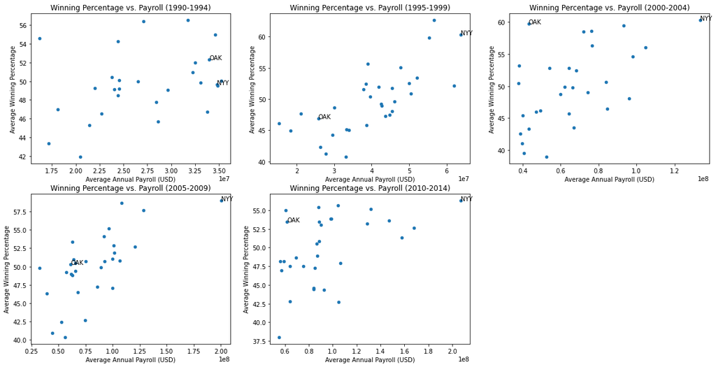

```python
# creates 5 subplots
fig_p4, axes = plt.subplots(nrows=2, ncols=3, figsize=(20, 10))
fig_p4.delaxes(axes[1][2])

# plots the data
means.loc["A"].plot.scatter(x="payroll", y="winPercent", ax=axes[0][0], title="Winning Percentage vs. Payroll (1990-1994)")
# adds a label "OAK" for the point representing the Oakland A's
axes[0, 0].text(means.loc["A"].at["OAK", "payroll"], means.loc["A"].at["OAK", "winPercent"], "OAK")
# adds a label "NYY" for the point representing the New York Yankees
axes[0, 0].text(means.loc["A"].at["NYA", "payroll"], means.loc["A"].at["NYA", "winPercent"], "NYY")

means.loc["B"].plot.scatter(x="payroll", y="winPercent", ax=axes[0][1], title="Winning Percentage vs. Payroll (1995-1999)")
axes[0, 1].text(means.loc["B"].at["OAK", "payroll"], means.loc["B"].at["OAK", "winPercent"], "OAK")
axes[0, 1].text(means.loc["B"].at["NYA", "payroll"], means.loc["B"].at["NYA", "winPercent"], "NYY")

means.loc["C"].plot.scatter(x="payroll", y="winPercent", ax=axes[0][2], title="Winning Percentage vs. Payroll (2000-2004)")
axes[0, 2].text(means.loc["C"].at["OAK", "payroll"], means.loc["C"].at["OAK", "winPercent"], "OAK")
axes[0, 2].text(means.loc["C"].at["NYA", "payroll"], means.loc["C"].at["NYA", "winPercent"], "NYY")

means.loc["D"].plot.scatter(x="payroll", y="winPercent", ax=axes[1][0], title="Winning Percentage vs. Payroll (2005-2009)")
axes[1, 0].text(means.loc["D"].at["OAK", "payroll"], means.loc["D"].at["OAK", "winPercent"], "OAK")
axes[1, 0].text(means.loc["D"].at["NYA", "payroll"], means.loc["D"].at["NYA", "winPercent"], "NYY")

means.loc["E"].plot.scatter(x="payroll", y="winPercent", ax=axes[1][1], title="Winning Percentage vs. Payroll (2010-2014)")
axes[1, 1].text(means.loc["E"].at["OAK", "payroll"], means.loc["E"].at["OAK", "winPercent"], "OAK")
axes[1, 1].text(means.loc["E"].at["NYA", "payroll"], means.loc["E"].at["NYA", "winPercent"], "NYY")

plt.setp(axes, xlabel="Average Annual Payroll (USD)")
# added "_ =" for clean output
_ = plt.setp(axes, ylabel="Average Winning Percentage")
```

To create the 5 plots, I first used the `groupby()` function in Pandas to group the data by chunks of time and team, and take the mean payroll and winning percentage for teams in each. I chose the 5 groups that I did (between 1990-2014) because each time chunk is equal, and we can compare results with results in problems 2 and 3. I then plotted the values for teams within each time chunk on 5 different plots. I chose to label two teams on the plots to make analysis easier. The Oakland A's are labeled "OAK", and the New York Yankees are labeled "NYY".

I chose these teams becase the A's are known having used analytics to win while spending less than other teams, while the Yankees are known for spending a lot of money (also becase I am a Yankees fan). Both of these teams don't rename or move in 1990-2014, so they are in all 5 plots.

### Question 2

In general, it's easy to see a slight trend upward in most of these graphs, meaning teams that spend more money tend to have a higher winning percentage. It is not until 2010-2014 that you begin to see many teams be near the top in winning percentage that are on the lower end of the league in terms of average annual payroll.

The first thing I noticed when looking at these graphs is the Yankees' increase in spending between 1995-1999 and 2005-2009. In the former their average payroll appears to be around \$65 million a year, whereas in the latter it is around \$200 million, and by then the Yankees have really become an outlier in spending. In the case of the Yankees, this does seem to translate into winning games, because their winning percentage is at or is very near the highest in the league for all three time chunks following their initial spending increase. You could say that the Yankees were particularly good at "paying for wins" from 1995 to 2014.

The first graph shows that the A's in 1990-1994 had one of the highest average annual payrolls in the MLB. However, in 1995-1999 their spending had not increased by nearly as much as other teams in the league, and they had one of the lowest average payrolls; their success seemed to reflect that, their winning percentage was below 50\% and was pretty low compared to most other teams over that span. In 2000-2004 their average payroll was still one of the lowest in the league but their winning percentage was one of the best—almost tied with the Yankees! Something must have happened around the turn of the millennium that helped the A's win games with much less money than other teams.

They remained low spenders relative to other teams in the next two time chunks, but always had a winning record on average (winning percent over 50\%). In 2005 to 2009 their winning percentage was only mediocre, but in 2010-2014 they were back to being near the top of the league.

# Part 3: Data transformations

## Standardizing Across Years

### Problem 5

```python
teams_temp = teams[["yearID", "payroll"]]

# adds columns for the mean and standard deviation payrolls in the row's yearID to each row
teams_temp = teams_temp.join(other=teams.groupby("yearID").mean()["payroll"], on="yearID", rsuffix="Mean")
teams_temp = teams_temp.join(other=teams.groupby("yearID").std()["payroll"], on="yearID", rsuffix="Std")
```

```python
# adds a column that contains the row's payroll, mean, and std as a tuple
teams_temp["asTuple"]= list(zip(teams_temp.payroll, teams_temp.payrollMean, teams_temp.payrollStd))
```

```python
# function to get standardized payroll
def standardize(tup):
    payroll, avg, std = tup
    return (payroll - avg) / std
```

```python
# transforms the column of tuples and adds the result to the teams dataframe
teams["standardizedPayroll"] = teams_temp.asTuple.transform(standardize)
```

```python
teams
```

|  | yearID | teamID | ... | payroll | standardizedPayroll |
| --- | --- | --- | --- | --- | --- |
| 0 | 1985 | ATL | ... | 14807000.0 | 1.914905 |
| 1 | 1985 | BAL | ... | 11560712.0 | 0.601068 |
| 2 | 1985 | BOS | ... | 10897560.0 | 0.332678 |
| 3 | 1985 | CAL | ... | 14427894.0 | 1.761474 |
| 4 | 1985 | CHA | ... | 9846178.0 | -0.092838 |
| ... | ... | ... | ... | ... | ... |
| 853 | 2014 | SLN | ... | 120693000.0 | 0.457126 |
| 854 | 2014 | TBA | ... | 72689100.0 | -0.593171 |
| 855 | 2014 | TEX | ... | 112255059.0 | 0.272509 |
| 856 | 2014 | TOR | ... | 109920100.0 | 0.221422 |
| 857 | 2014 | WAS | ... | 131983680.0 | 0.704160 |

858 rows × 8 columns

To transform the data using `.transform()`, I wanted to input the payroll, the average payroll, and the standard deviation as a tuple. To get the data in that format, I first made two new columns in a temporary dataframe for the average and standard deviation. Then I used `zip()` to combine them into a new column of tuples.

Using a function I defined that takes in a tuple and gives the standardized payroll, I transformed the column of tulples and added the result to my dataset.

### Problem 6

```python
# can reuse the "bins" series from before

# creates new dataframe with a bin column and select columns from the teams dataframe
binned = teams.drop(teams.columns.difference(["teamID", "winPercent", "standardizedPayroll"]), 1).join(bins)

means = binned.groupby(by=["bin", "teamID"]).mean()
means = means.dropna()
```

```python
means
```

| bin | teamID | winPercent | standardizedPayroll |
| --- | --- | --- | --- |
| A | ATL | 56.497726 | 0.381441 |
|  | BAL | 50.444080 | -0.658533 |
|  | BOS | 49.514761 | 1.014231 |
|  | CAL | 45.704777 | 0.338304 |
|  | CHA | 56.426308 | -0.309019 |
| ... | ... | ... | ... |
| E | SLN | 55.679012 | 0.199817 |
|  | TBA | 54.992047 | -0.850728 |
|  | TEX | 53.881694 | 0.036064 |
|  | TOR | 48.888889 | -0.274002 |
|  | WAS | 53.024308 | -0.195302 |

151 rows × 2 columns

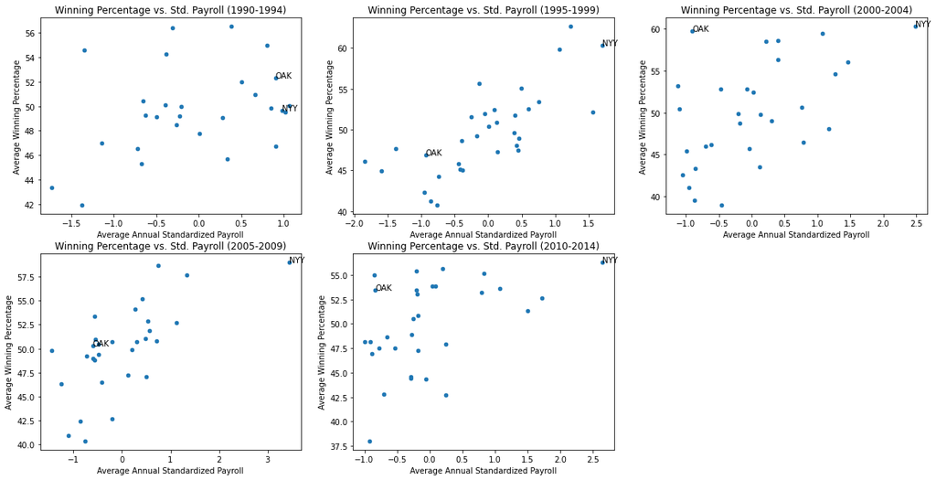

```python
# creates 5 subplots
fig, axes = plt.subplots(nrows=2, ncols=3, figsize=(20, 10))
fig.delaxes(axes[1][2])

# plots the data
means.loc["A"].plot.scatter(x="standardizedPayroll", y="winPercent", ax=axes[0][0], title="Winning Percentage vs. Std. Payroll (1990-1994)")
# adds a label "OAK" for the point representing the Oakland A's
axes[0, 0].text(means.loc["A"].at["OAK", "standardizedPayroll"], means.loc["A"].at["OAK", "winPercent"], "OAK")
# adds a label "NYY" for the point representing the New York Yankees
axes[0, 0].text(means.loc["A"].at["NYA", "standardizedPayroll"], means.loc["A"].at["NYA", "winPercent"], "NYY")

means.loc["B"].plot.scatter(x="standardizedPayroll", y="winPercent", ax=axes[0][1], title="Winning Percentage vs. Std. Payroll (1995-1999)")
axes[0, 1].text(means.loc["B"].at["OAK", "standardizedPayroll"], means.loc["B"].at["OAK", "winPercent"], "OAK")
axes[0, 1].text(means.loc["B"].at["NYA", "standardizedPayroll"], means.loc["B"].at["NYA", "winPercent"], "NYY")

means.loc["C"].plot.scatter(x="standardizedPayroll", y="winPercent", ax=axes[0][2], title="Winning Percentage vs. Std. Payroll (2000-2004)")
axes[0, 2].text(means.loc["C"].at["OAK", "standardizedPayroll"], means.loc["C"].at["OAK", "winPercent"], "OAK")
axes[0, 2].text(means.loc["C"].at["NYA", "standardizedPayroll"], means.loc["C"].at["NYA", "winPercent"], "NYY")

means.loc["D"].plot.scatter(x="standardizedPayroll", y="winPercent", ax=axes[1][0], title="Winning Percentage vs. Std. Payroll (2005-2009)")
axes[1, 0].text(means.loc["D"].at["OAK", "standardizedPayroll"], means.loc["D"].at["OAK", "winPercent"], "OAK")
axes[1, 0].text(means.loc["D"].at["NYA", "standardizedPayroll"], means.loc["D"].at["NYA", "winPercent"], "NYY")

means.loc["E"].plot.scatter(x="standardizedPayroll", y="winPercent", ax=axes[1][1], title="Winning Percentage vs. Std. Payroll (2010-2014)")
axes[1, 1].text(means.loc["E"].at["OAK", "standardizedPayroll"], means.loc["E"].at["OAK", "winPercent"], "OAK")
axes[1, 1].text(means.loc["E"].at["NYA", "standardizedPayroll"], means.loc["E"].at["NYA", "winPercent"], "NYY")

plt.setp(axes, xlabel="Average Annual Standardized Payroll")
# added "_ =" for clean output
_ = plt.setp(axes, ylabel="Average Winning Percentage")
```

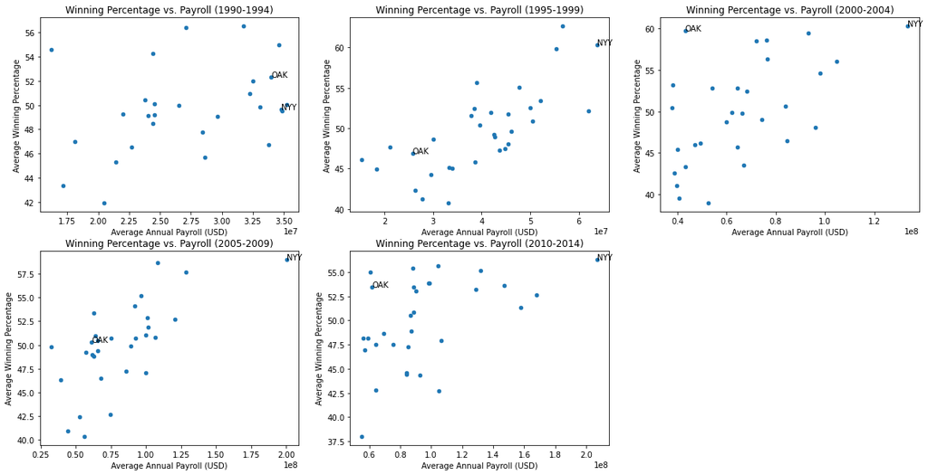

```python
# figure from problem 4 for comparison
fig_p4
```

I used the same code to get the same graphs from problem 4, only this time I used standardized payroll instead of payroll for the x-axis.

### Question 3

The plots in problem 4 and problem 6 look very similar, except in problem 6 instead of plotting winning percentage against payroll, we're plotting it against the standardized payroll: the number of standard deviations that the given team is from the mean payroll of that year. They look similar because a team with a high payroll is also going to have a high standardized payroll, and a team with a low payroll will also have a low standardized payroll.

We can see from these graphs that the general slight trend of upward still exists after the transform, implying that higher standardized payroll is correlated with higher winning percentage similarly to how actual payroll is.

The significance of this transform is that now payroll is relative to the other payrolls in its year, so we can compare data across years without worrying about the the overall increase in payrolls over time found in problem 2. The x-axis labels between some of the graphs differ in the plots with actual payroll by an order of magnitude due to the overall increase in payrolls. In the plots with standardized payroll, the x values stay much more consistent throughout the 5 graphs—there is a slight change due to the New York Yankees becoming a spending outlier, but in general the x values stay within the range of -2 to 2.

## Expected Wins

### Problem 7

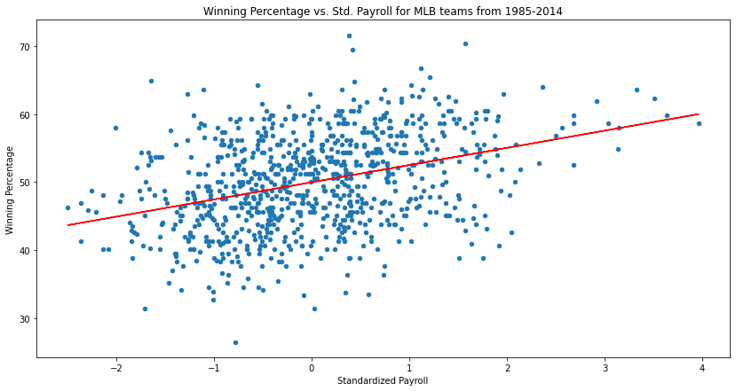

```python
fig, axes = plt.subplots(figsize=(14, 7))

# plots data
teams.plot.scatter(x="standardizedPayroll", y="winPercent", ax=axes, title="Winning Percentage vs. Std. Payroll for MLB teams from 1985-2014")
plt.setp(axes, xlabel="Standardized Payroll", ylabel="Winning Percentage")

# calculates polynomial for best fit line
fit = np.polyfit(x=teams.standardizedPayroll, y=teams.winPercent, deg=1)
fun = np.poly1d(fit)

# plots best fit line
x = teams.standardizedPayroll
y = fun(x)
_ = axes.plot(x, y, color="r")
```

The code in this section is pretty straightforward. The x and y coordinates for each team was already in my dataset under the standardized payroll and winning percentage columns. I used that to plot the data, and then used that data along with `numpy.polyfit()` to get the best fit line.

## Spending Efficiency

### Problem 8

```python
# calculates a series for all expected win percents based on equation given in project description
ex_win_pcts = teams.standardizedPayroll.transform(lambda x: 50 + 2.5*x)
```

```python
# creates a series with win percent and expected win percent in a tuple for each team
tups = pd.Series(list(zip(teams.winPercent, ex_win_pcts)))
```

```python
def get_efficiency(tup):
    win_pct, ex_win_pct = tup
    return win_pct - ex_win_pct
```

```python
# adds column for efficiency to teams dataframe
teams["efficiency"] = tups.transform(get_efficiency)
```

```python
teams
```

|  | yearID | teamID | ... | standardizedPayroll | efficiency |
| --- | --- | --- | --- | --- | --- |
| 0 | 1985 | ATL | ... | 1.914905 | -14.046522 |
| 1 | 1985 | BAL | ... | 0.601068 | 0.050124 |
| 2 | 1985 | BOS | ... | 0.332678 | -1.138442 |
| 3 | 1985 | CAL | ... | 1.761474 | 1.151872 |
| 4 | 1985 | CHA | ... | -0.092838 | 2.379333 |
| ... | ... | ... | ... | ... | ... |
| 853 | 2014 | SLN | ... | 0.457126 | 4.412740 |
| 854 | 2014 | TBA | ... | -0.593171 | -0.986208 |
| 855 | 2014 | TEX | ... | 0.272509 | -9.323248 |
| 856 | 2014 | TOR | ... | 0.221422 | 0.681014 |
| 857 | 2014 | WAS | ... | 0.704160 | 7.498860 |

858 rows × 9 columns

```python
# creates dataframe with yearID as the index and each team's efficiency as a column
efficiencies = teams[["yearID", "teamID", "efficiency"]].set_index("yearID").pivot(columns="teamID")
```

```python
efficiencies
```

| teamID yearID | efficiency ANA | efficiency ARI | efficiency ... | efficiency TOR | efficiency WAS |
| --- | --- | --- | --- | --- | --- |
| 1985 | NaN | NaN | ... | 12.768601 | NaN |
| 1986 | NaN | NaN | ... | 2.156328 | NaN |
| 1987 | NaN | NaN | ... | 9.261966 | NaN |
| 1988 | NaN | NaN | ... | 3.197726 | NaN |
| 1989 | NaN | NaN | ... | 3.246073 | NaN |
| ... | ... | ... | ... | ... | ... |
| 2010 | NaN | -7.909220 | ... | 4.337034 | -5.484807 |
| 2011 | NaN | 10.424539 | ... | 1.852951 | 1.463425 |
| 2012 | NaN | 1.626481 | ... | -3.393570 | 11.641575 |
| 2013 | NaN | 0.564140 | ... | -5.607958 | 2.443765 |
| 2014 | NaN | -10.387793 | ... | 0.681014 | 7.498860 |

30 rows × 35 columns

```python
# removes "efficiency" from column names for cleaner legend when plotted
efficiencies.columns = efficiencies.columns.droplevel()
```

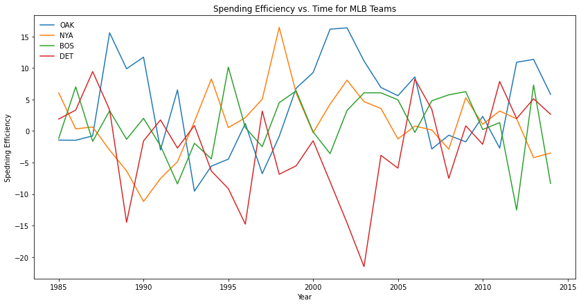

```python
fig, axes = plt.subplots(figsize=(14, 7))

# plots the data
efficiencies[["OAK", "NYA", "BOS", "DET"]].plot(ax=axes, title="Spending Efficiency vs. Time for MLB Teams")
plt.setp(axes, xlabel="Year", ylabel="Spedning Efficiency")

# customizes legend
_ = axes.legend(frameon=False, loc='upper left', ncol=1)
```

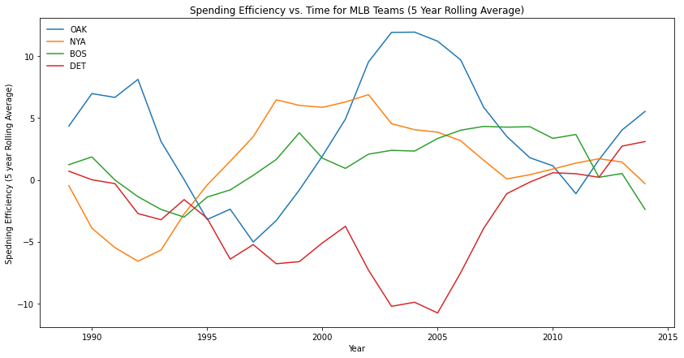

```python
fig, axes = plt.subplots(figsize=(14, 7))

# plots the rolling average of the data
efficiencies[["OAK", "NYA", "BOS", "DET"]].rolling(5).mean().plot(ax=axes, title="Spending Efficiency vs. Time for MLB Teams (5 Year Rolling Average)")
plt.setp(axes, xlabel="Year", ylabel="Spedning Efficiency (5 year Rolling Average)")

# customizes legend
_ = axes.legend(frameon=False, loc='upper left', ncol=1)
```

To get efficiency for each team, I made a series of tuples that contained win percent and expected win percent, and then used `.transform()` to subtract expected win percent from win percent. I then used `.pivot()` to get a dataframe with columns for the efficiency of each team where rows are each year; this way the data would be easier to plot.

I decided to plot the Oakland A's (OAK) and the New York Yankees (NYA) to be able to compare with the graphs in problems 4 and 6. I also wanted to plot other teams for context; I decided on the the Boston Red Sox (BOS), a team whose spending efficiency is pretty middle-of-the-road and stays around the 0 mark, and the Detroit Tigers (DET), who seem to have poor spending efficiency in general.

After seeing my initial plot, I decided to also look at the 5 year rolling average to make the trends easier to see.

### Question 4

This plot shows teams' performance compared to how they were expected to perform based on their payroll, as defined by spedning efficiency. Teams with low standardized payroll and high winning percent on a graph in problem 6 should be shown to have a high spending efficiency here over the years of the specific graph in problem 6.

In question 2 I said I thought the New York Yankees were particularly good at "paying for wins", especially after 1995, because their spending and winning percentage was high. I did not know how efficient that spending was, however. They could have reached diminishing returns. From this graph you can see that the Yankees had a spending efficiency averaging above zero for a while from the late '90s to the late 2000s, so they actually were winning more than they would be expected to based on their payroll.

The Oakland A's, we know from question 2, had one of the lowest average annual payrolls in the league but one of the highest winning percentages from 2000-2004. From this we would expect that they were overacheaving based on expectations and should have a high spending efficiency over that span—and they do! In what looks like 2001 and 2002, they had a winning percentage around 15 points higher than would be predicted based on the regression line in problem 7; and on the rolling average graph you can clearly see they are very efficient on average in that time period.